# Assignment 01

Erik Pak

January 27, 2023

## Problem 1

The file banking.txt attached to this assignment provides data acquired from banking and census records for different zip codes in the bank’s current market. Such information can be useful in targeting advertising for new customers or for choosing locations for branch offices.

The data show:

- median age of the population (AGE)
- median income (INCOME) in $
- average bank balance (BALANCE) in $
- median years of education (EDUCATION)

Use R to compute the analysis below. All the functions are in the code for that we covered in class so far and in the exercises. This is the first assignment, and for many of you it may be the first time you use R. So if you run into an error, post a message on the discussion board or contact me. Make sure to include your code in the message.

#### Libraries

```r
library(psych)         # used for describe
library(ggplot2)       # used for ggplot
library(aplpack)       # stem leaf plot
library(ggpubr)        # combine scatter plots
library(QuantPsyc)     # normalize coefficients
library(equatiomatic)  # equation for a model
```

#### Import text file

```r
bank <- read.table("../Data/Banking.txt", header = TRUE)
```

#### Assign Variable

```r
balance <- bank$Balance
```

#### Display

```r
str(bank)
```

```
## 'data.frame':    102 obs. of  4 variables:
##  $ Age      : num  35.9 37.7 36.8 35.3 35.3 34.8 39.3 36.6 35.7 40.5 ...
##  $ Education: num  14.8 13.8 13.8 13.2 13.2 13.7 14.4 13.9 16.1 15.1 ...
##  $ Income   : int  91033 86748 72245 70639 64879 75591 80615 76507 107935 82557 ...
##  $ Balance  : int  38517 40618 35206 33434 28162 36708 38766 34811 41032 41742 ...
```

```r
describe(balance)
```

```
##    vars   n     mean      sd  median  trimmed     mad  min   max range skew
## X1    1 102 24887.88 8697.81 24660.5 24546.44 6834.04 5956 56569 50613 0.59
##    kurtosis     se
## X1     1.27 861.21
```

```r
summary(balance)
```

```
##    Min. 1st Qu.  Median    Mean 3rd Qu.    Max.
##    5956   20036   24660   24888   29180   56569
```

#### Histogram a)

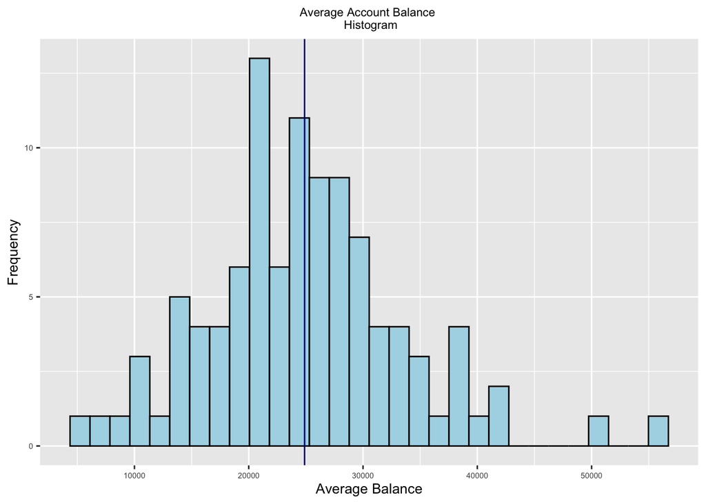

```r
plot_hist_bal <- ggplot(bank, aes(x=Balance)) +
                  geom_histogram(bins = 30, color="black", fill="lightblue") +
                  geom_vline(aes(xintercept=mean(Balance)), col="darkblue") +
                  labs(title = "Average Account Balance \n Histogram",
                       x = "Average Balance", y = 'Frequency') +
                  # move the title text to the middle
                  theme(plot.title=element_text(hjust=0.5)) +
                  theme(text = element_text(size = 7))  +
                  theme(axis.title = element_text(size = 10))

plot_hist_bal
```

#### Stem Plot a) Extra

```r
stem.leaf(balance, m = 3)
```

```
## 1 | 2: represents 12000
##  leaf unit: 1000
##             n: 102
##     2    0 | 56
##     4    0 | 99
##     7    1 | 001
##    16    1 | 334445566
##    25    1 | 677788999
##    45    2 | 00000001111111222233
##   (17)   2 | 33344444455566666
##    40    2 | 6677777788888999999
##    21    3 | 1112222
##    14    3 | 3445
##    10    3 | 67788
##     5    4 | 011
##          4 |
##          4 |
##     2    5 | 1
## HI: 56569
```

#### Scatter Plots b)

[figure not shown]

```r
#
age_plot       <- ggplot(bank, aes(x=Age, y=Balance)) +
                  geom_point() +
                  geom_smooth(method=lm, se=FALSE) +
                  labs(title="Average Balance  \n according to the Age",
                  x="Age (Years)", y = "Balance (US Dollars)") +
                  # move the title text to the middle
                  theme(plot.title=element_text(hjust=0.5)) +
                  theme(text = element_text(size = 7))  +
                  theme(axis.title = element_text(size = 10))

education_plot <- ggplot(bank, aes(x=Age, y=Education)) +
                  geom_point() +
                  geom_smooth(method=lm, se=FALSE) +
                  labs(title="Average Balance  \n according to the Education",
                       x="Education (Years)", y = "Balance (US Dollars)") +
                  # move the title text to the middle
                  theme(plot.title=element_text(hjust=0.5))  +
                  theme(text = element_text(size = 7))  +
                  theme(axis.title = element_text(size = 10))

income_plot    <- ggplot(bank, aes(x=Age, y=Income)) +
                  geom_point() +
                  geom_smooth(method=lm, se=FALSE) +
                  labs(title="Average Balance  \n according to the Income",
                       x="Income ( per $1,000)", y = "Balance (US Dollars)") +
                  # move the title text to the middle
                  theme(plot.title=element_text(hjust=0.5)) +
                  theme(text = element_text(size = 7))  +
                  theme(axis.title = element_text(size = 10))
# combine all plots
all_plot <- ggarrange(plot_hist_bal, age_plot, education_plot, income_plot,
                      labels = c("Fig A", "Fig B", "Fig C", "Fig D"),
                      font.label = list(size = 7, color = "blue"))
# plot all
all_plot
```

#### Correlation c)

```r
# correlation values
cor(bank)
```

```
##                 Age Education    Income   Balance
## Age       1.0000000 0.1734071 0.4771474 0.5654668
## Education 0.1734071 1.0000000 0.5753940 0.5548807
## Income    0.4771474 0.5753940 1.0000000 0.9516845
## Balance   0.5654668 0.5548807 0.9516845 1.0000000
```

### Multiple Linear Regression Model

#### d)

```r
# display the actual coefficients
equatiomatic::extract_eq(bank_model, use_coefs = FALSE)
```

[output not shown]

$$\operatorname{Balance} = \alpha + \beta_{1}(\operatorname{Age}) +
\beta_{2}(\operatorname{Education}) + \beta_{3}(\operatorname{Income}) +
\epsilon$$

#### Multiple Linear Regression Model e)

```r
# display the actual coefficients
equatiomatic::extract_eq(bank_model, use_coefs = TRUE)
```

$$\operatorname{\widehat{Balance}} = -9539.95 + 332.5(\operatorname{Age})
+ 288.66(\operatorname{Education}) + 0.39(\operatorname{Income})$$

#### Bank Model Info

```r
# standardized regression coefficients
lm.beta(bank_model)
```

```
##        Age  Education     Income
## 0.14857228 0.03335784 0.86159971
```

```r
#
summary(bank_model) # show results
```

```
##
## Call:
## lm(formula = Balance ~ Age + Education + Income, data = bank)
##
## Residuals:
##     Min      1Q  Median      3Q     Max
## -7722.0 -1547.4   -56.1  1167.9  8480.2
##
## Coefficients:
##               Estimate Std. Error t value Pr(>|t|)
## (Intercept) -9.540e+03  4.423e+03  -2.157   0.0335 *
## Age          3.325e+02  7.234e+01   4.597 1.28e-05 ***
## Education    2.887e+02  3.005e+02   0.960   0.3392
## Income       3.871e-01  1.748e-02  22.137  < 2e-16 ***
## ---
## Signif. codes:  0 '***' 0.001 '**' 0.01 '*' 0.05 '.' 0.1 ' ' 1
##
## Residual standard error: 2458 on 98 degrees of freedom
## Multiple R-squared:  0.9225, Adjusted R-squared:  0.9201
## F-statistic: 388.8 on 3 and 98 DF,  p-value: < 2.2e-16
```

#### New Model f)

```r
# new model without education since t value from summary
# has p-value greaten than 0.05
#
new_bank_model <- lm(Balance ~ Age + Income, data=bank)
# show the theoretical model
equatiomatic::extract_eq(new_bank_model)
```

$$\operatorname{Balance} = \alpha + \beta_{1}(\operatorname{Age}) +
\beta_{2}(\operatorname{Income}) + \epsilon$$

#### i)

```r
# display the actual coefficients
equatiomatic::extract_eq(new_bank_model, use_coefs = TRUE)
```

$$\operatorname{\widehat{Balance}} = -5912.22 + 322.72(\operatorname{Age})
+ 0.4(\operatorname{Income})$$

###### Given:

Median Age = 34.8 & Median Education = 12.5 & Median Income = $42,401 & Average balance = $21,572

```r
# predicted value
given = data.frame(Age = c(34.8), Education = c(12.5) ,Income = c(42401), Balance = c(21572))
# first model
predict(bank_model, given, interval="prediction")
```

```
##       fit      lwr      upr
## 1 22050.6 17142.66 26958.53
```

```r
# first model prediction error
(given$Balance-predict(bank_model, given))
```

```
##         1
## -478.5961
```

```r
# second model
predict(new_bank_model, given, interval="prediction")
```

```
##        fit      lwr     upr
## 1 22135.22 17232.94 27037.5
```

```r
# second model prediction error
(given$Balance-predict(new_bank_model, given))
```

```
##         1
## -563.2155
```

#### Global F-test j)

$$H_0: \beta_1 = \beta_2 = 0$$

$$H_a: \text {At least one of the coefficients is non-zero}$$

```r
# summary
anova(new_bank_model)
```

```
## Analysis of Variance Table
##
## Response: Balance
##           Df     Sum Sq    Mean Sq F value    Pr(>F)
## Age        1 2443180856 2443180856  404.61 < 2.2e-16 ***
## Income     1 4599872720 4599872720  761.78 < 2.2e-16 ***
## Residuals 99  597790568    6038289
## ---
## Signif. codes:  0 '***' 0.001 '**' 0.01 '*' 0.05 '.' 0.1 ' ' 1
```

## Problem 4

A survey of IS managers was used to predict the yearly salary of beginning programmer analysts in a metropolitan area. Managers specified their standard salary (SALARY) in $1000 for a beginning programmer/analyst, the number of employees (NUMEMPL) in the firm’s information processing staff, the firm’s gross profit margin (MARGIN) in cents per dollar of sales and the firm’s information processing cost (IPCOST) as a percentage of total administrative costs.

We’ll fit a regression model to evaluate if starting salaries are affected by either the number of IS employees, IP costs and margin profits. The data is in salary_IS.txt.

```r
# import text file with header
sal <- read.table("../Data/salary_IS.txt", header = TRUE)
```

### 1)

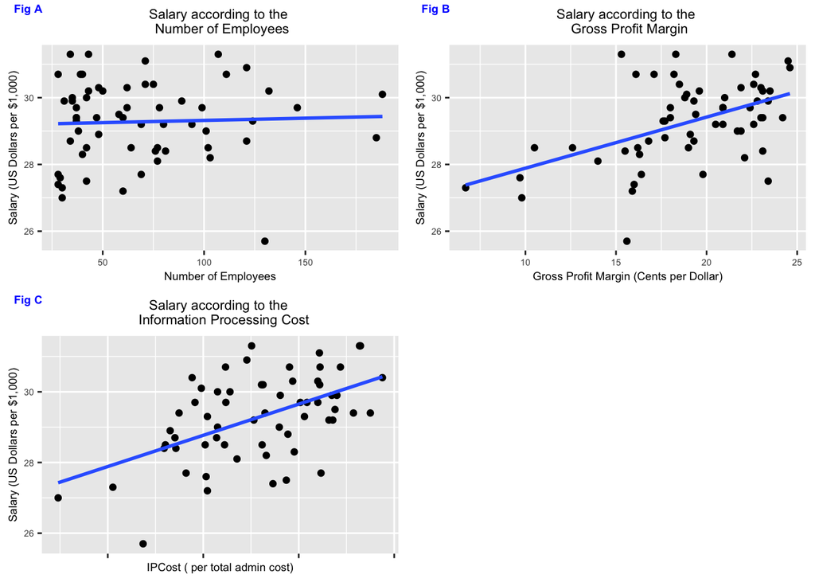

```r
#
numempl_plot <- ggplot(sal, aes(x=numempl, y=salary)) +
                geom_point() +
                geom_smooth(method=lm, se=FALSE) +
                labs(title="Salary according to the \n Number of Employees",
                     x="Number of Employees", y = "Salary (US Dollars per $1,000)") +
                # move the title text to the middle
                theme(plot.title=element_text(hjust=0.5)) +
                theme(text = element_text(size = 7))  +
                theme(axis.title = element_text(size = 7))

margin_plot <- ggplot(sal, aes(x=margin, y=salary)) +
               geom_point() +
               geom_smooth(method=lm, se=FALSE) +
               labs(title="Salary according to the \n Gross Profit Margin",
                     x="Gross Profit Margin (Cents per Dollar)",
                    y = "Salary (US Dollars per $1,000)") +
               # move the title text to the middle
               theme(plot.title=element_text(hjust=0.5))  +
               theme(text = element_text(size = 7))  +
               theme(axis.title = element_text(size = 7))

ipcost_plot <- ggplot(sal, aes(x=ipcost, y=salary)) +
               geom_point() +
               geom_smooth(method=lm, se=FALSE) +
               labs(title="Salary according to the \n  Information Processing Cost",
                     x="IPCost ( per total admin cost)", y = "Salary (US Dollars per $1,000)") +
               # move the title text to the middle
               theme(plot.title=element_text(hjust=0.5)) +
               theme(text = element_text(size = 7))  +
               theme(axis.title = element_text(size = 7))

# combine all three plots
all_plot <- ggarrange(numempl_plot, margin_plot, ipcost_plot + rremove("x.text"),
                      labels = c("Fig A", "Fig B", "Fig C"),
                      font.label = list(size = 7, color = "blue"))
# plot all
all_plot
```

```r
# correlation
cor(sal)
```

```
##             salary     numempl    margin      ipcost
## salary  1.00000000  0.04267267 0.4988443  0.52975765
## numempl 0.04267267  1.00000000 0.1257754 -0.09667573
## margin  0.49884432  0.12577542 1.0000000  0.55409931
## ipcost  0.52975765 -0.09667573 0.5540993  1.00000000
```

#### Regression Model 2)

```r
# regression model
salary_model <- lm(salary ~ numempl + margin + ipcost, data = sal)
# show the theoretical model
equatiomatic::extract_eq(salary_model)
```

$$\operatorname{salary} = \alpha + \beta_{1}(\operatorname{numempl}) +
\beta_{2}(\operatorname{margin}) + \beta_{3}(\operatorname{ipcost}) +
\epsilon$$

```r
# display the actual coefficients
equatiomatic::extract_eq(salary_model, use_coefs = TRUE)
```

$$\operatorname{\widehat{salary}} = 25.9 + 0(\operatorname{numempl}) +
0.09(\operatorname{margin}) + 0.21(\operatorname{ipcost})$$

#### 3)

```r
# original model summary
summary(salary_model)
```

```
##
## Call:
## lm(formula = salary ~ numempl + margin + ipcost, data = sal)
##
## Residuals:
##      Min       1Q   Median       3Q      Max
## -2.60018 -0.68845  0.04395  0.57401  2.16937
##
## Coefficients:
##              Estimate Std. Error t value Pr(>|t|)
## (Intercept) 25.900686   0.681101  38.028  < 2e-16 ***
## numempl      0.001356   0.003471   0.391  0.69747
## margin       0.087484   0.040529   2.159  0.03511 *
## ipcost       0.208865   0.073137   2.856  0.00598 **
## ---
## Signif. codes:  0 '***' 0.001 '**' 0.01 '*' 0.05 '.' 0.1 ' ' 1
##
## Residual standard error: 0.9997 on 57 degrees of freedom
## Multiple R-squared:  0.3432, Adjusted R-squared:  0.3087
## F-statistic: 9.929 on 3 and 57 DF,  p-value: 2.307e-05
```

```r
# standardized regression coefficients
lm.beta(salary_model)
```

```
##    numempl     margin     ipcost
## 0.04316034 0.28509795 0.37595763
```

#### Re-Fit Model 4)

```r
new_salary_model <- lm(salary ~ margin + ipcost, data = sal)
# show the theoretical model
equatiomatic::extract_eq(new_salary_model)
```

$$\operatorname{salary} = \alpha + \beta_{1}(\operatorname{margin}) +
\beta_{2}(\operatorname{ipcost}) + \epsilon$$

```r
# display the actual coefficients
equatiomatic::extract_eq(new_salary_model, use_coefs = TRUE)
```

$$\operatorname{\widehat{salary}} = 25.97 + 0.09(\operatorname{margin}) +
0.2(\operatorname{ipcost})$$

#### Coefficient of Determination [R^2] 5)

```r
# display R^2
summary(new_salary_model)$r.squared
```

```
## [1] 0.3414687
```

#### Analyze the Goodness of fit 6)

[figure not shown]

```r
#residuals vs fitted values plot
residual_plot <-  ggplot(new_salary_model, aes(x = .fitted, y = .resid)) +
                  geom_point() +
                  geom_hline(yintercept = 0, col = "red") +
                  labs(title="Fitted vs Residuals Plot",
                    x = "Fitted Values",
                    y = "Residual") +
                  # move the title text to the middle
                  theme(plot.title=element_text(hjust=0.5))  +
                  theme(text = element_text(size = 7))  +
                  theme(axis.title = element_text(size = 7))

#residuals vs margin variable
marginr_plot <- ggplot(sal, aes(x = margin, y = rstandard(new_salary_model))) +
                geom_point() +
                geom_hline(yintercept = 0, col = "red") +
                labs(title="Margin vs Residuals Plot",
                    x = "Margin(Cents per Dollar Sales)",
                    y = "Residual") +
                # move the title text to the middle
                theme(plot.title=element_text(hjust=0.5))  +
                theme(text = element_text(size = 7))  +
                theme(axis.title = element_text(size = 7))
#residuals vs ipcost variable
ipcostr_plot <- ggplot(sal, aes(x = ipcost, y = rstandard(new_salary_model))) +
                geom_point() +
                geom_hline(yintercept = 0, col = "red") +
                labs(title="IPCost vs Residuals Plot",
                    x = "Margin(Cents per Dollar Sales)",
                    y = "Residual") +
                # move the title text to the middle
                theme(plot.title=element_text(hjust=0.5))  +
                theme(text = element_text(size = 7))  +
                theme(axis.title = element_text(size = 7))


#create Q-Q plot
qq_plot <-  ggplot(new_salary_model, aes(sample=rstandard(new_salary_model))) +
            stat_qq(size=1.5, color='blue') +
            stat_qq_line(col = "red") +
            labs(title="Normal Q-Q Plot",
              x = "Theoretical Quantiles",
              y = "Sample Quantiles") +
            # move the title text to the middle
            theme(plot.title=element_text(hjust=0.5))  +
            theme(text = element_text(size = 7))  +
            theme(axis.title = element_text(size = 7))


# combine all four plots
residualt_plot <-  ggarrange(residual_plot, marginr_plot, ipcostr_plot,qq_plot,
                   labels = c("Fig A", "Fig B", "Fig C", "Fig D"),
                   font.label = list(size = 7, color = "blue"))
# plot all
residualt_plot
```

```r
# summary of new model
summary(new_salary_model)
```

```
##
## Call:
## lm(formula = salary ~ margin + ipcost, data = sal)
##
## Residuals:
##     Min      1Q  Median      3Q     Max
## -2.5260 -0.5797  0.0490  0.6611  2.1359
##
## Coefficients:
##             Estimate Std. Error t value Pr(>|t|)
## (Intercept) 25.97304    0.65063  39.920  < 2e-16 ***
## margin       0.09091    0.03928   2.315  0.02420 *
## ipcost       0.20311    0.07111   2.856  0.00594 **
## ---
## Signif. codes:  0 '***' 0.001 '**' 0.01 '*' 0.05 '.' 0.1 ' ' 1
##
## Residual standard error: 0.9923 on 58 degrees of freedom
## Multiple R-squared:  0.3415, Adjusted R-squared:  0.3188
## F-statistic: 15.04 on 2 and 58 DF,  p-value: 5.479e-06
```

```r
# ANOVA
anova(new_salary_model)
```

```
## Analysis of Variance Table
##
## Response: salary
##           Df Sum Sq Mean Sq F value    Pr(>F)
## margin     1 21.582 21.5819 21.9170 1.757e-05 ***
## ipcost     1  8.033  8.0330  8.1578  0.005942 **
## Residuals 58 57.113  0.9847
## ---
## Signif. codes:  0 '***' 0.001 '**' 0.01 '*' 0.05 '.' 0.1 ' ' 1
```

```r
# sumnary of old model
summary(salary_model)
```

```
##
## Call:
## lm(formula = salary ~ numempl + margin + ipcost, data = sal)
##
## Residuals:
##      Min       1Q   Median       3Q      Max
## -2.60018 -0.68845  0.04395  0.57401  2.16937
##
## Coefficients:
##              Estimate Std. Error t value Pr(>|t|)
## (Intercept) 25.900686   0.681101  38.028  < 2e-16 ***
## numempl      0.001356   0.003471   0.391  0.69747
## margin       0.087484   0.040529   2.159  0.03511 *
## ipcost       0.208865   0.073137   2.856  0.00598 **
## ---
## Signif. codes:  0 '***' 0.001 '**' 0.01 '*' 0.05 '.' 0.1 ' ' 1
##
## Residual standard error: 0.9997 on 57 degrees of freedom
## Multiple R-squared:  0.3432, Adjusted R-squared:  0.3087
## F-statistic: 9.929 on 3 and 57 DF,  p-value: 2.307e-05
```

#### Standarized Coefficients of the model 7)

```r
# New model
lm.beta(new_salary_model)
```

```
##    margin    ipcost
## 0.2962680 0.3655958
```